# Assignment 3

Nickie Mitch

9/18/2020

### Load Libraries

```r
library(tidyverse)
library(ggplot2)
```

### Load and Mutate Data

```r
hh_data <- read_csv("household_data_me.csv") %>%
  mutate(LANGUAGE = case_when(
    HHLANP_label=="English only household"~"English",
     HHLANP_label=="Spanish"~"Spanish",
    HHLANP_label=="French"~"French",
    HHLANP_label=="Japanese"~"Some other language",
    HHLANP_label=="Korean"~"Some other language",
    HHLANP_label=="German"~"Some other language",
    HHLANP_label=="Other Native North American languages"~"Some other language",
    HHLANP_label=="Arabic"~"Some other language",
    HHLANP_label=="Thai"~"Some other language",
    HHLANP_label=="Italian"~"Some other language",
    HHLANP_label=="Chinese"~"Some other language",
    HHLANP_label=="Pennsylvania German"~"Some other language",
    HHLANP_label=="Urdu"~"Some other language",
    HHLANP_label=="Cebuano"~"Some other language",
    HHLANP_label=="Tagalog"~"Some other language",
    HHLANP_label=="Romanian"~"Some other language",
    HHLANP_label=="Other Bantu languages"~"Some other language",
    HHLANP_label=="Bosnian"~"Some other language",
    HHLANP_label=="Hindi"~"Some other language",
    HHLANP_label=="Portuguese"~"Some other language",
    HHLANP_label=="Mandarin"~"Some other language",
    HHLANP_label=="Cantonese"~"Some other language",
    HHLANP_label=="Filipino"~"Some other language",
    HHLANP_label=="Bengali"~"Some other language",
    HHLANP_label=="Somali"~"Some other language",
    HHLANP_label=="Serbian"~"Some other language",
    HHLANP_label=="Russian"~"Some other language",
    HHLANP_label=="Vietnamese"~"Some other language",
    HHLANP_label=="Lithuanian"~"Some other language",
    HHLANP_label=="Farsi"~"Some other language",
    HHLANP_label=="Turkish"~"Some other language",
    HHLANP_label=="Tamil"~"Some other language",
    HHLANP_label=="Finnish"~"Some other language",
    HHLANP_label=="Telugu"~"Some other language",
    HHLANP_label=="Swahili"~"Some other language",
    HHLANP_label=="Greek"~"Some other language",
    HHLANP_label=="Dutch"~"Some other language",
    HHLANP_label=="Polish"~"Some other language",
    HHLANP_label=="Swahili"~"Some other language",
    HHLANP_label=="Chamorro"~"Some other language"),
  INTERNET = case_when(
    ACCESS_label=="Yes, by paying a cell phone company or Internet service provider"~"Yes",
    ACCESS_label=="No access to the Internet at this house, apartment, or mobile home"~"No",
    ACCESS_label=="Yes, without paying a cell phone company or Internet service provider"~"Yes"))
```

### Relationship Between Household Income (HINCP) and Number of Persons (NP)

These are two continuous variables. There is a fairly weak, statistically significant positive correlation between them.

```r
correlation <- cor.test(hh_data$HINCP, hh_data$NP)

correlation
```

```
##
##  Pearson's product-moment correlation
##
## data:  hh_data$HINCP and hh_data$NP
## t = 28.44, df = 12504, p-value < 2.2e-16
## alternative hypothesis: true correlation is not equal to 0
## 95 percent confidence interval:
##  0.2299501 0.2628742
## sample estimates:
##       cor
## 0.2464833
```

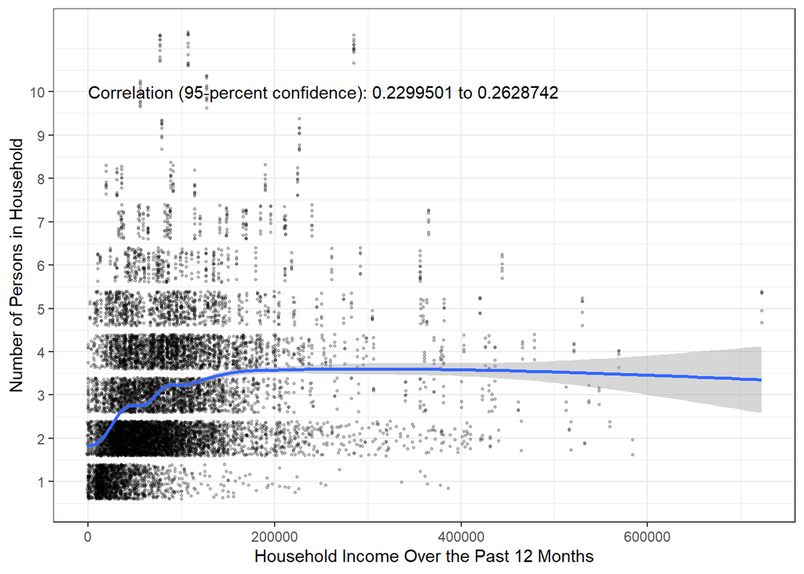

```r
options(scipen=10000)
ggplot(hh_data, aes(x = HINCP, y = NP)) +
  geom_point(size = 0.5, alpha = 0.25, position = "jitter") +
  geom_smooth() +
  theme_bw() +
  scale_x_continuous(name = "Household Income Over the Past 12 Months") +
  scale_y_continuous(name = "Number of Persons in Household",
                     breaks = seq(0, 10, by = 1),
                     labels = paste(prettyNum(seq(0, 10, by = 1),
                                              big.mark = ","))) +
  annotate(geom = "text", x = 0, y = 10,
           label = paste("Correlation (95-percent confidence):",
                         prettyNum(correlation$conf.int[1]),
                         "to",
                         prettyNum(correlation$conf.int[2])),
           hjust = 0)
```

### Relationship Between Household Income (HINCP) and Number of Related Children (NRC)

These are two continuous variables. There is a weak, statistically significant positive correlation between them.

```r
correlation <- cor.test(hh_data$HINCP, hh_data$NRC)

correlation
```

```
##
##  Pearson's product-moment correlation
##
## data:  hh_data$HINCP and hh_data$NRC
## t = 12.641, df = 12504, p-value < 0.00000000000000022
## alternative hypothesis: true correlation is not equal to 0
## 95 percent confidence interval:
##  0.09499214 0.12960307
## sample estimates:
##       cor
## 0.1123317
```

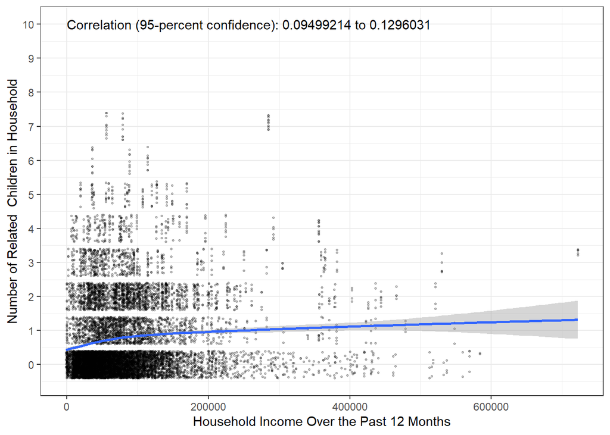

```r
options(scipen=10000)
ggplot(hh_data, aes(x = HINCP, y = NRC)) +
  geom_point(size = 0.5, alpha = 0.25, position = "jitter") +
  geom_smooth() +
  theme_bw() +
  scale_x_continuous(name = "Household Income Over the Past 12 Months") +
  scale_y_continuous(name = "Number of Related  Children in Household",
                     breaks = seq(0, 10, by = 1),
                     labels = paste(prettyNum(seq(0, 10, by = 1),
                                              big.mark = ","))) +
  annotate(geom = "text", x = 0, y = 10,
           label = paste("Correlation (95-percent confidence):",
                         prettyNum(correlation$conf.int[1]),
                         "to",
                         prettyNum(correlation$conf.int[2])),
           hjust = 0)
```

### Relationship Between Household Income (HINCP) and Internet Access (INTERNET)

These are a continuous variable and a binary variable. There is a statistically significant relationship between them.

```r
difference1 = t.test(HINCP ~ INTERNET == "Yes",
                    data = hh_data)

difference1
```

```
##
##  Welch Two Sample t-test
##
## data:  HINCP by INTERNET == "Yes"
## t = -30.508, df = 1728.8, p-value < 0.00000000000000022
## alternative hypothesis: true difference in means is not equal to 0
## 95 percent confidence interval:
##  -48131.92 -42316.94
## sample estimates:
## mean in group FALSE  mean in group TRUE
##            41563.95            86788.38
```

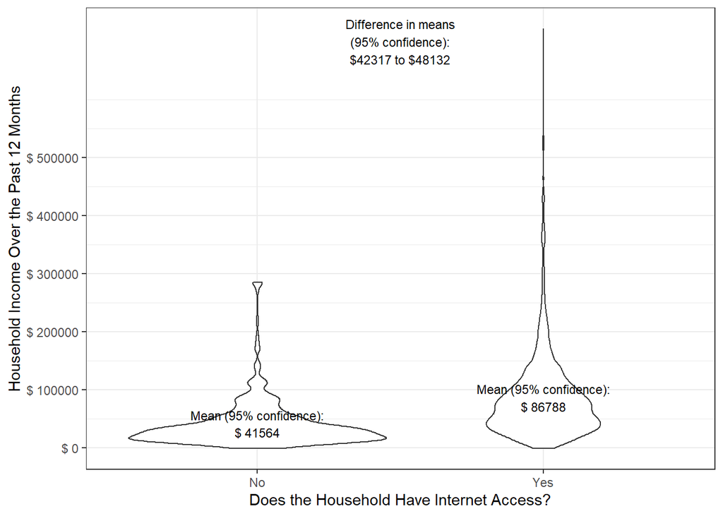

```r
ggplot(hh_data, aes(x = INTERNET, y = HINCP)) +
  geom_violin() +
  theme_bw() +
  scale_x_discrete(name = "Does the Household Have Internet Access?",
                   labels = c("No", "Yes")) +
   scale_y_continuous(name = "Household Income Over the Past 12 Months",
                     breaks = seq(0, 500000, by = 100000),
                     labels = paste("$", prettyNum(seq(0, 500000, by = 100000)))) +
  annotate(geom = "text", x = 1.5, y = 700000, size = 3,
           label = paste("Difference in means\n(95% confidence):\n$",
                         prettyNum(abs(difference1$conf.int[2]),
                                   digits = 0), " to $",
                         prettyNum(abs(difference1$conf.int[1]),
                                   digits = 0),
                         sep = "")) +
  annotate(geom = "text", x = 1, y = difference1$estimate[1], size = 3,
           label = paste("Mean (95% confidence):\n$",
                         prettyNum(difference1$estimate[1], digits = 0))) +
  annotate(geom = "text", x = 2, y = difference1$estimate[2], size = 3,
           label = paste("Mean (95% confidence):\n$",
                         prettyNum(difference1$estimate[2], digits = 0)))
```

### Relationship Between Household Income (HINCP) and Household Language (LANGUAGE)

These are a continuous variable and a categorical variable. There is a statistically significant relationship between them.

```r
anova <- aov(HINCP ~ LANGUAGE, data = hh_data)

summary(anova)
```

```
##                Df         Sum Sq      Mean Sq F value              Pr(>F)
## LANGUAGE        3   614885613326 204961871109   39.23 <0.0000000000000002 ***
## Residuals   12502 65325731588350   5225222491
## ---
## Signif. codes:  0 '***' 0.001 '**' 0.01 '*' 0.05 '.' 0.1 ' ' 1
```

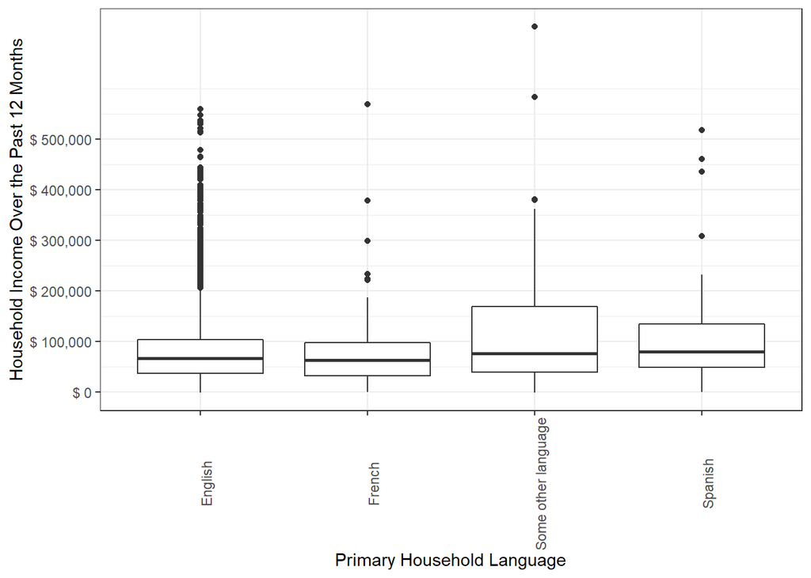

```r
ggplot(hh_data, aes(x = LANGUAGE, y = HINCP)) +
  geom_boxplot() +
  theme_bw() +
  theme(axis.text.x = element_text(angle = 90)) +
  scale_x_discrete(name = "Primary Household Language") +
  scale_y_continuous(name = "Household Income Over the Past 12 Months",
                      breaks = seq(0, 500000, by = 100000),
                     labels = paste("$",
                                    prettyNum(seq(0, 500000, by = 100000),
                                              big.mark = ",")))
```

### Relationship Between Numper of Persons (NP) and Household Language (LANGUAGE)

These are a continuous variable and a categorical variable. There is a stastically signficant relationship between them.

```r
anova <- aov(NP ~ LANGUAGE, data = hh_data)

summary(anova)
```

```
##                Df Sum Sq Mean Sq F value              Pr(>F)
## LANGUAGE        3    502  167.17   73.95 <0.0000000000000002 ***
## Residuals   12502  28261    2.26
## ---
## Signif. codes:  0 '***' 0.001 '**' 0.01 '*' 0.05 '.' 0.1 ' ' 1
```

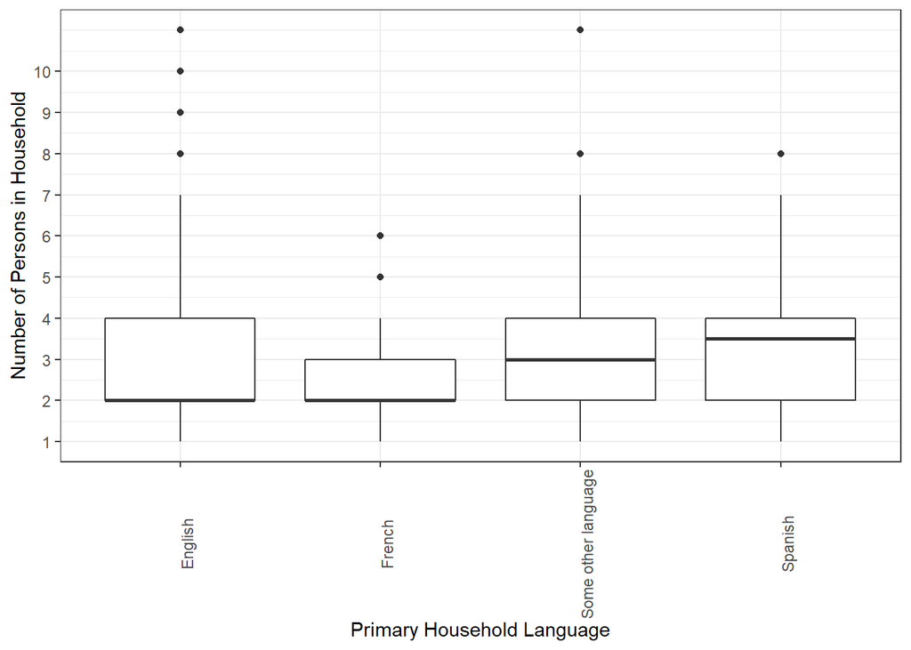

```r
ggplot(hh_data, aes(x = LANGUAGE, y = NP)) +
  geom_boxplot() +
  theme_bw() +
  theme(axis.text.x = element_text(angle = 90)) +
  scale_x_discrete(name = "Primary Household Language") +
  scale_y_continuous(name = "Number of Persons in Household",
                      breaks = seq(0, 10, by = 1),
                     labels = paste((seq(0, 10, by = 1))))
```

### Relationship Between Number of Related Children (NRC) and Household Language (LANGUAGE)

These are a continuous variable and a categorical variable. There is a statistically signficant relationship between them.

```r
anova <- aov(NRC ~ LANGUAGE, data = hh_data)

summary(anova)
```

```
##                Df Sum Sq Mean Sq F value              Pr(>F)
## LANGUAGE        3    213   71.03   51.96 <0.0000000000000002 ***
## Residuals   12502  17092    1.37
## ---
## Signif. codes:  0 '***' 0.001 '**' 0.01 '*' 0.05 '.' 0.1 ' ' 1
```

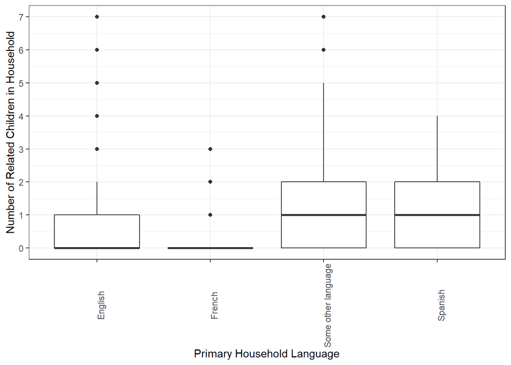

```r
ggplot(hh_data, aes(x = LANGUAGE, y = NRC)) +
  geom_boxplot() +
  theme_bw() +
  theme(axis.text.x = element_text(angle = 90)) +
  scale_x_discrete(name = "Primary Household Language") +
  scale_y_continuous(name = "Number of Related Children in Household",
                      breaks = seq(0, 15, by = 1),
                     labels = paste((seq(0, 15, by = 1))))
```

### Relationship Between Internet Access (INTERNET) and Household Language (LANGUAGE)

```r
chi_sq <- chisq.test(hh_data$LANGUAGE, hh_data$INTERNET ==
                       "Yes")

chi_sq
```

```
##
##  Pearson's Chi-squared test
##
## data:  hh_data$LANGUAGE and hh_data$INTERNET == "Yes"
## X-squared = 10.079, df = 3, p-value = 0.01791
```

Instructions for making this mosaic plot were found at https://stackoverflow.com/questions/19233365/how-to-create-a-marimekko-mosaic-plot-in-ggplot2

```r
df <- hh_data %>%
  group_by(LANGUAGE, INTERNET) %>%
  summarise(count = n()) %>%
  mutate(prop = count/sum(count)) %>%
  ungroup()
```

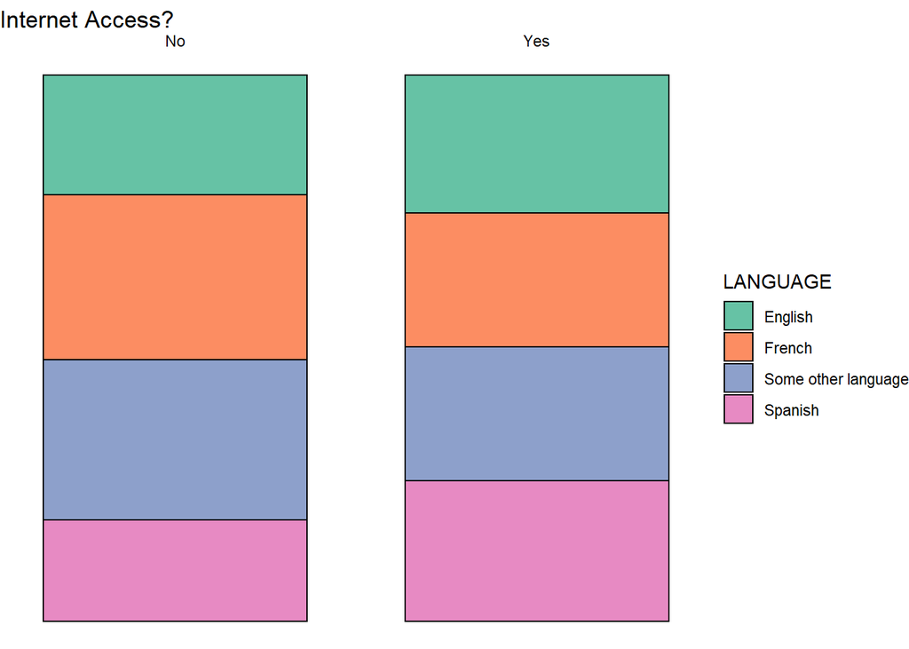

```r
ggplot(df, aes(x = INTERNET, y = prop, fill = LANGUAGE)) +
  geom_bar(stat = "identity", position = "fill", colour = "black") +
  facet_grid(~INTERNET, scales = "free_x", space = "free_x") +
  scale_fill_brewer(palette = "Set2") +
  ggtitle("Internet Access?") +
  theme_void()
```

### Relationship Between Number of Persons (NP) and Number of Related Children (NRC)

These are two continuous variables. There is a strong, statistically significant positive correlation between them.

```r
correlation <- cor.test(hh_data$NP, hh_data$NRC)

correlation
```

```
##
##  Pearson's product-moment correlation
##
## data:  hh_data$NP and hh_data$NRC
## t = 167.44, df = 12504, p-value < 0.00000000000000022
## alternative hypothesis: true correlation is not equal to 0
## 95 percent confidence interval:
##  0.8261256 0.8369391
## sample estimates:
##       cor
## 0.8316111
```

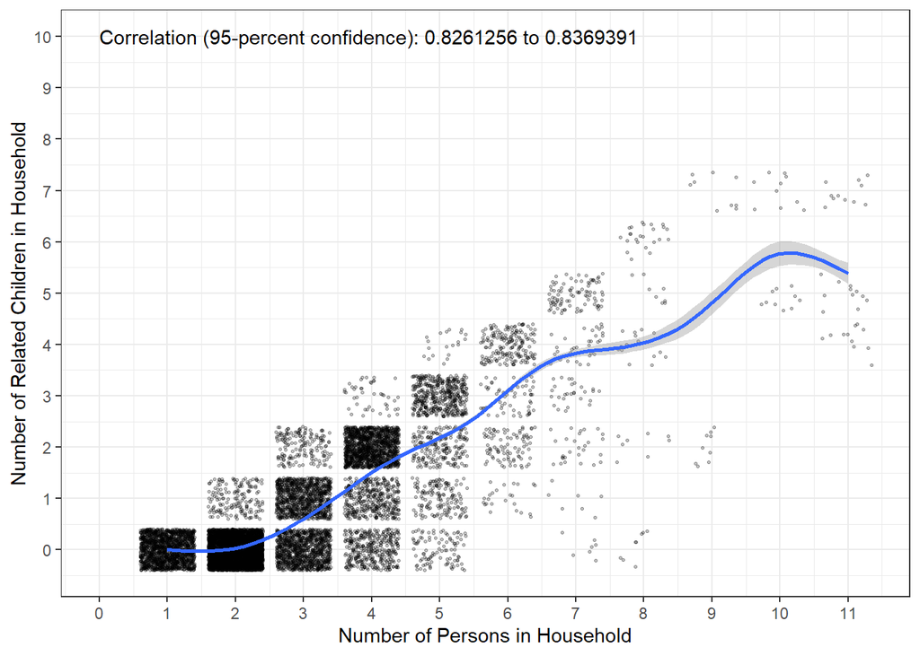

```r
options(scipen=10000)
ggplot(hh_data, aes(x = NP, y = NRC)) +
  geom_point(size = 0.5, alpha = 0.25, position = "jitter") +
  geom_smooth() +
  theme_bw() +
  scale_x_continuous(name = "Number of Persons in Household",
                     breaks = seq(0, 15, by = 1),
                     labels = paste(prettyNum(seq(0, 15, by = 1),
                                              big.mark = ",")))+
  scale_y_continuous(name = "Number of Related Children in Household",
                     breaks = seq(0, 15, by = 1),
                     labels = paste(prettyNum(seq(0, 15, by = 1),
                                              big.mark = ","))) +
  annotate(geom = "text", x = 0, y = 10,
           label = paste("Correlation (95-percent confidence):",
                         prettyNum(correlation$conf.int[1]),
                         "to",
                         prettyNum(correlation$conf.int[2])),
           hjust = 0)
```

### Relationship Between Number of Persons (NP) and Internet Access (INTERNET)

These are a continuous variable and a binary variable. There is a statistically significant relationship between them.

```r
difference2 = t.test(NP ~ INTERNET == "Yes",
                    data = hh_data)

difference2
```

```
##
##  Welch Two Sample t-test
##
## data:  NP by INTERNET == "Yes"
## t = -20.979, df = 1290.3, p-value < 0.00000000000000022
## alternative hypothesis: true difference in means is not equal to 0
## 95 percent confidence interval:
##  -1.0726653 -0.8892021
## sample estimates:
## mean in group FALSE  mean in group TRUE
##            1.994403            2.975337
```

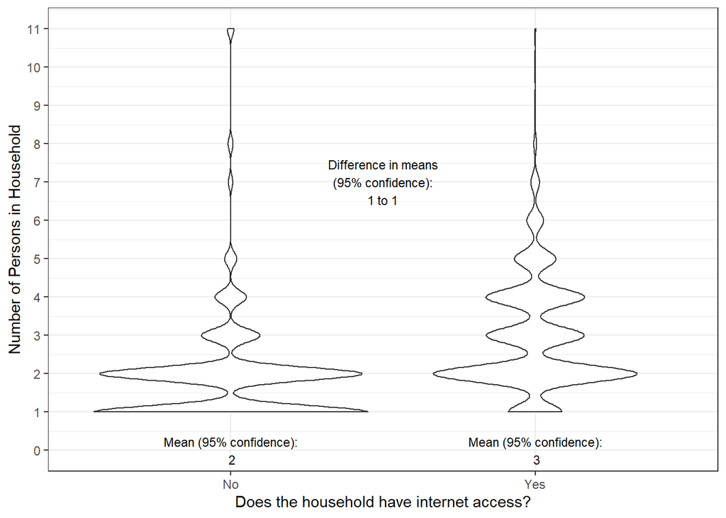

```r
ggplot(hh_data, aes(x = INTERNET, y = NP)) +
  geom_violin() +
  theme_bw() +
  scale_x_discrete(name = "Does the household have internet access?",
                   labels = c("No", "Yes")) +
   scale_y_continuous(name = "Number of Persons in Household",
                     breaks = seq(0, 15, by = 1),
                     labels = paste(prettyNum(seq(0, 15, by = 1)))) +
  annotate(geom = "text", x = 1.5, y = 7, size = 3,
           label = paste("Difference in means\n(95% confidence):\n",
                         prettyNum(abs(difference2$conf.int[2]),
                                   digits = 0), " to ",
                         prettyNum(abs(difference2$conf.int[1]),
                                   digits = 0),
                         sep = "")) +
  annotate(geom = "text", x = 1, y = 0, size = 3,
           label = paste("Mean (95% confidence):\n",
                         prettyNum(difference2$estimate[1], digits = 0))) +
  annotate(geom = "text", x = 2, y = 0, size = 3,
           label = paste("Mean (95% confidence):\n",
                         prettyNum(difference2$estimate[2], digits = 0)))
```

### Relationship Between Number of Related Children (NRC) and Internet Access (INTERNET)

These are a continuous variable and a binary variable. There is a statistically signficant relationship between them.

```r
difference3 = t.test(NRC ~ INTERNET == "Yes",
                    data = hh_data)

difference3
```

```
##
##  Welch Two Sample t-test
##
## data:  NRC by INTERNET == "Yes"
## t = -13.45, df = 1325.5, p-value < 0.00000000000000022
## alternative hypothesis: true difference in means is not equal to 0
## 95 percent confidence interval:
##  -0.5324947 -0.3969345
## sample estimates:
## mean in group FALSE  mean in group TRUE
##           0.3199627           0.7846773
```

[figure not shown]

```r
ggplot(hh_data, aes(x = INTERNET, y = NP)) +
  geom_violin() +
  theme_bw() +
  scale_x_discrete(name = "Does the household have Internet Access?",
                   labels = c("No", "Yes")) +
   scale_y_continuous(name = "Number of Related Children",
                     breaks = seq(0, 15, by = 1),
                     labels = paste(prettyNum(seq(0, 15, by = 1)))) +
  annotate(geom = "text", x = 1.5, y = 7, size = 3,
           label = paste("Difference in means\n(95% confidence):\n",
                         prettyNum(abs(difference3$conf.int[2]),
                                   digits = 0), " to ",
                         prettyNum(abs(difference3$conf.int[1]),
                                   digits = 0),
                         sep = "")) +
  annotate(geom = "text", x = 1, y = 0, size = 3,
           label = paste("Mean (95% confidence):\n",
                         prettyNum(difference3$estimate[1], digits = 0))) +
  annotate(geom = "text", x = 2, y = 0, size = 3,
           label = paste("Mean (95% confidence):\n",
                         prettyNum(difference3$estimate[2], digits = 0)))
```